# Identification of monotonic trend in the dose-response relationship of nanomaterial toxicity

# 1. Introduction: NMTox

NMTox is an R package created to perform data exploration and to identify monotone trend in the dose-response relationship of nanomaterial toxicity. It consists of functions generating frequency tables and graphical displays and functions performing inference to test the monotonic trend. This document shows how NMTox can be used to perform data exploration and inference.

# 2. Dataset

Data of genetic toxicity in vitro (`geninvitro`) and NM-104 (Titanium Dioxide) (`nm104`) studies are available as examples in this package. These data are subset of data of NanoinformaTIX project that are available in the eNanoMapper database. For more information about the datasets, `?geninvitro` or `?nm104` can be used. `geninvitro`contains variables:

```r
names(geninvitro)
```

```
##  [1] "name"                  "publicname"            "supplier"
##  [4] "experimentID"          "topcategory"           "method"
##  [7] "studyprovider"         "endpoint"              "value"
## [10] "unit"                  "celltype"              "treatment"
## [13] "exptimeunit"           "exptime"               "concentration_unit"
## [16] "concentration"         "concentration_ml_unit" "concentration_ml"
## [19] "replicate"             "passagenum"
```

with the first 5 observations given below

```r
geninvitro[1:5,]
```

```
##      name publicname    supplier                         experimentID
## 1 control    CONTROL NanoGenotox da92beeb-b74e-31be-b41d-002dc964ddbc
## 2 control    CONTROL NanoGenotox da92beeb-b74e-31be-b41d-002dc964ddbc
## 3 control    CONTROL NanoGenotox ed6464b0-637f-38da-876d-72f9d6e7d95a
## 4 control    CONTROL NanoGenotox ed6464b0-637f-38da-876d-72f9d6e7d95a
## 5 control    CONTROL NanoGenotox 9354ddc4-cf64-3425-b364-7addf8a1491d
##   topcategory    method studyprovider          endpoint value          unit
## 1         TOX     COMET           IPH DNA STRAND BREAKS 11.15 % DNA in Tail
## 2         TOX     COMET           IPH DNA STRAND BREAKS 23.81 % DNA in Tail
## 3         TOX COMET FPG           IPH DNA STRAND BREAKS  8.35 % DNA in Tail
## 4         TOX COMET FPG           IPH DNA STRAND BREAKS  4.22 % DNA in Tail
## 5         TOX     COMET         NRCWE DNA STRAND BREAKS  5.60 % DNA in Tail
##   celltype treatment exptimeunit exptime concentration_unit concentration
## 1  BEAS-2B   Control           h     3.0             ug/cm2           0.0
## 2  BEAS-2B   Control           h     3.0             ug/cm2           0.0
## 3  BEAS-2B   Control           h     3.0             ug/cm2           0.0
## 4  BEAS-2B   Control           h     3.0             ug/cm2           0.0
## 5    16HBE   Control           h    24.0             ug/cm2           0.0
##   concentration_ml_unit concentration_ml replicate passagenum
## 1                 ug/ml                0      <NA>       <NA>
## 2                 ug/ml                0      <NA>       <NA>
## 3                 ug/ml                0      <NA>       <NA>
## 4                 ug/ml                0      <NA>       <NA>
## 5                 ug/ml                0      <NA>       <NA>
```

# 3. Methodology

In the dose-response analysis of nanomaterial toxicity, it is assumed that the toxicity endpoints increase or decrease monotonically.

### M test and modified M test

M test:
$$\begin{equation}
M=\frac{\hat{\mu}^\star(x_K)-\hat{\mu}^\star(x_0)}{\sqrt{\sum_{i=0}^{K}\sum_{j=1}^{n_i}(y_{ij}-\hat{\mu_i}^\star)^2/(N-K)}}
\end{equation}$$

Modified M test:
$$\begin{equation}
M=\frac{\hat{\mu}^\star(x_K)-\hat{\mu}^\star(x_0)}{\sqrt{\sum_{i=0}^{K}\sum_{j=1}^{n_i}(y_{ij}-\hat{\mu_i}^\star)^2/(N-I)}}
\end{equation}$$

### William and Marcus test

$$\begin{equation}
t_i=\frac{\hat{\mu}^\star(x_i)-\bar{y}_0}{\sqrt{2s^2/n}}
\end{equation}$$

$$\begin{equation}
t_i=\frac{\hat{\mu}^\star(x_i)-\hat{\mu}^\star(x_0)}{\sqrt{s^2/n_i+s^2/n_0}}
\end{equation}$$

### Likelihood ratio test

The test statistics is given by:
$$\begin{equation}
\Lambda_{01}^{\frac{2}{N}}=\frac{\hat{\sigma}_{H_1}^2}{\hat{\sigma}_{H_0}^2}=\frac{\sum_{ij}(y_{ij}-\hat{\mu}_i^{\star})^2}{\sum_{ij}(y_{ij}-\hat{\mu})^2}=\frac{RSS_1}{RSS_0}
\end{equation}$$

$$\begin{equation}
\bar{E}_{01}^2=1-\Lambda_{01}^{\frac{2}{N}}
\end{equation}$$

### Adjustment of Multiplicity

# 4. Case study: Genetic toxicity in vitro

This example consists of the result of studies related to genetic toxicity. It is of interest to see if there is any significant monotonic trend in the dose-response relationship of the nanomaterial toxicity. First, frequency tables and scatter plots are generated to explore the dataset, especially to explore the toxicity endpoints, the nanomaterials, and other possibly important variables. Then, inference for order-restricted data using several methods is performed to identify the siginificant monotonic trend.

## 4.1 Data exploration

Function `FrTab` can be used to explore the variables in the `geninvitro` dataset. `FrTab` produces the number of unique values, the list of unique values or the number of observations of certain variable(s) in the dataset.

Exploration on each variable in `geninvitro` dataset shows that the concentration used in the experiment is stored in two different variables, `concentration` and `concentration_ml`, with their units stored in variable `concentration_unit` and `concentration_ml_unit` respectively.

```r
Frtab(data=geninvitro, x="concentration_unit", opt="list")
```

```
## [1] "ug/cm2" NA
```

```r
Frtab(data=geninvitro, x="concentration_ml_unit", opt="list")
```

```
## [1] "ug/ml" NA
```

Concentrations used in the experiments are stored in variable `concentration` and `concentration_ml.`, with their units of measurements are stored in variable `concentration_unit` and `concentration_ml_unit` respectively. As seen above, variable `concentration_unit` contains observations with `ug/cm2` unit, while variable (`concentration_ml_unit`) stores `ug/ml` unit. Both variables appear to contain missing information. It is also possible that a variable (of unit of measurement) contains several units of measurements used in different studies/experiments. Further exploration of the data shows that for many observations, concentrations in both concentration variables are available, while for some the concentration is only available in one of the variables. Since only one variable of concentration will be used in the analysis, to make further exploration and analysis easier, we will fill the missing concentration in one variable from concentration in another variable.

```r
geninvitro$concentration<-ifelse(is.na(geninvitro$concentration),
                                 geninvitro$concentration_ml,
                                 geninvitro$concentration)

geninvitro$concentration_unit<-ifelse(is.na(geninvitro$concentration_unit),
                                      geninvitro$concentration_ml_unit,
                                      geninvitro$concentration_unit)

geninvitro$concentration<-ifelse(geninvitro$concentration==0,
                                 "0.0",
                                 geninvitro$concentration)
```

From now on, we will use concentration and unit of measurement in variable `concentration` and `concentration_unit`. Function `FrTab` can also be used to explore the type of the nanomaterial in the study, as follows:

```r
Frtab(data=geninvitro, x="name", opt="ls.obs")
```

```
##                                     name   n
## 1                                control 273
## 2                                Control  94
## 3          NM-110 (Zinc Oxide, uncoated) 489
## 4 NM-400 (Multi-walled carbon nanotubes) 185
```

It can be seen that there are 4 different names identified in `geninvitro` data, which consists of 2 nanomaterials (NM-110 (Zinc Oxide, uncoated) and NM-400 (Multi-walled carbon nanotubes)) and control observations named as “`control`” and “`Control`”. The number of observations for each nanomaterial/control can be seen in column `n`. The toxicity endpoints measured for each nanomaterial can be explored using `FrTabs` as follows:

```r
Frtab(data=geninvitro, x=c("name","endpoint"), opt="ls.obs")
```

```
##                                     name          endpoint   n
## 1                                control DNA STRAND BREAKS 186
## 2                                control   MNBNC FREQUENCY  87
## 3                                Control DNA STRAND BREAKS  62
## 4                                Control   MNBNC FREQUENCY  32
## 5          NM-110 (Zinc Oxide, uncoated) DNA STRAND BREAKS 342
## 6          NM-110 (Zinc Oxide, uncoated)   MNBNC FREQUENCY 147
## 7 NM-400 (Multi-walled carbon nanotubes) DNA STRAND BREAKS 162
## 8 NM-400 (Multi-walled carbon nanotubes)   MNBNC FREQUENCY  23
```

```r
#FrTabs(geninvitro, x="endpoint", cat="name")
```

This package allows the exploration (such as scatter plot of the dose-response relationship) and (trend identification) analysis of all nanomaterials in the dataset simultaneously. The functions in this package identify different nanomaterials based on the names of the nanomaterials. As seen in the exploration there are control observations which are named differently, as `control` or `Control`, in `geninvitro` dataset. These control observations must be linked to the non-control observations belong to the same experiment. This can be done by first creating a separate dataset for these control observations. The linking of the observations can be performed by adding experiment identifier in the argument of several functions in this package.

Example:

```r
controldata<-SubsetData(data=geninvitro, x="name", x.cat=c("control","Control"))

invitrodata<-SubsetData(data=geninvitro, x="name", x.cat=c("control","Control"), include=FALSE)
```

Here, `controldata` is created by selecting the control observations named as `control` and `Control` from `geninvitro`, while `invitrodata` is `geninvitro` without these observations. If control observations are not named differently, this process can be ignored.

Suppose that we are interested in a specific toxicity endpoint “`DNA STRAND BREAKS`” with a specific concentration unit “`ug/cm2`”, scatter plots of the dose-response relationship can be generated as follows:

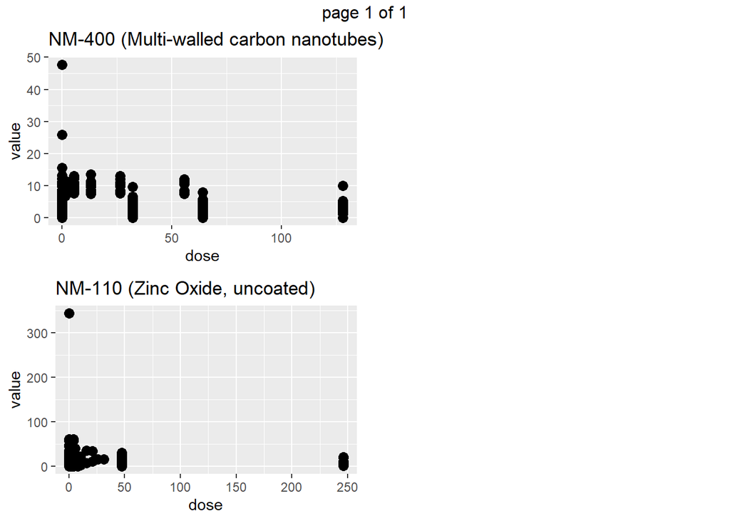

```r
nmplot(data.nm=invitrodata, data.control=controldata, id="experimentID", nano="name", response="value", dose="concentration", end="endpoint", end.cat="DNA STRAND BREAKS", unit="concentration_unit", unit.cat="ug/cm2", type="dose", control.opt="same", nrow=2, ncol=2)
```

Here, `experimentID` is the experiment identifier used to identify observations that belong to the same experiment. By specifying `same` (default) in the `control.opt`, only control doses with the same unit of measurement (in this case, `ug/cm2`) are included. If `all` is specified then control doses in other units of measurement are also included. To explore how many controls are available if all units of measurement of control are included and if only unit “ug/cm2” is included, function `FrCtrl` can be used:

```r
FrCtrl(data.nm=invitrodata, data.control=controldata, id="experimentID", nano="name", end="endpoint", end.cat="DNA STRAND BREAKS", dose="concentration", unit="concentration_unit", unit.cat="ug/cm2")
```

```
##                             Nanomaterial Freq(Dose=0.0).same Freq(obs).same
## 1          NM-110 (Zinc Oxide, uncoated)                 215            493
## 2 NM-400 (Multi-walled carbon nanotubes)                  93            253
##   Freq(Dose=0.0).all Freq(obs).all
## 1                223           501
## 2                 93           253
```

```r
FrCtrl(data.nm=invitrodata, data.control=controldata, id="experimentID", nano="name", end="endpoint", end.cat="DNA STRAND BREAKS", dose="concentration", unit="concentration_unit", unit.cat="ug/ml")
```

```
##                             Nanomaterial Freq(Dose=0.0).same Freq(obs).same
## 1          NM-110 (Zinc Oxide, uncoated)                   8             71
## 2 NM-400 (Multi-walled carbon nanotubes)                  NA              2
##   Freq(Dose=0.0).all Freq(obs).all
## 1                223           286
## 2                 93            95
```

If we want to explore all units of measurements, scatter plots of the dose-response relationship for each nanomaterial differentiated by the concentration unit can be generated:

```
## $`NM-400 (Multi-walled carbon nanotubes)`
```

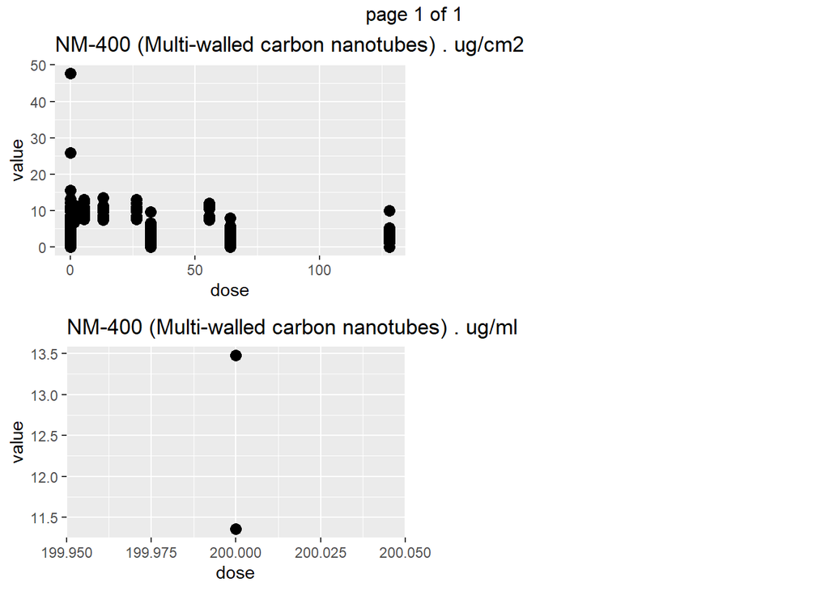

```
##
## $`NM-110 (Zinc Oxide, uncoated)`
```

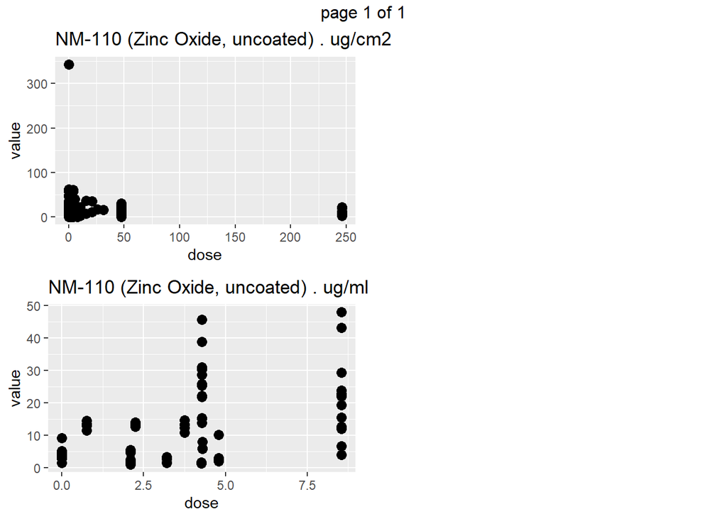

```r
nmplot(data.nm=invitrodata, data.control=controldata, id="experimentID", nano="name", response="value", dose="concentration", end="endpoint", end.cat="DNA STRAND BREAKS", type="dose", nrow=2, ncol=2, vars="concentration_unit")
```

The experiments in `geninvitro` were performed in several different cell types.

```r
#FrTabs.n(geninvitro, x="endpoint", x.cat="DNA STRAND BREAKS", cat="celltype")
```

It might be of interest to see if these cell types affect the dose-response relationship. Therefore, taking into account these cell types, scatter plots can be generated as follows:

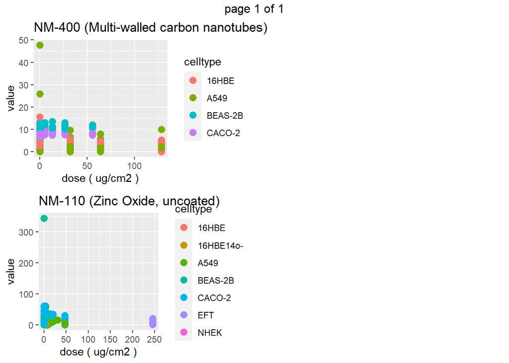

```r
nmplot.cat(data.nm=invitrodata, data.control=controldata, id="experimentID", nano="name", response="value", dose="concentration", end="endpoint", end.cat="DNA STRAND BREAKS", unit="concentration_unit", unit.cat="ug/cm2", type="dose", nrow=2, ncol=2, x.cat="celltype")
```

If we want to explore all endpoints and units of measurements, taking into account the cell types, scatter plots of the data subset (by the endpoint and concentration unit), with different colours represent different cell types can be generated:

```
## $`NM-400 (Multi-walled carbon nanotubes)`
```

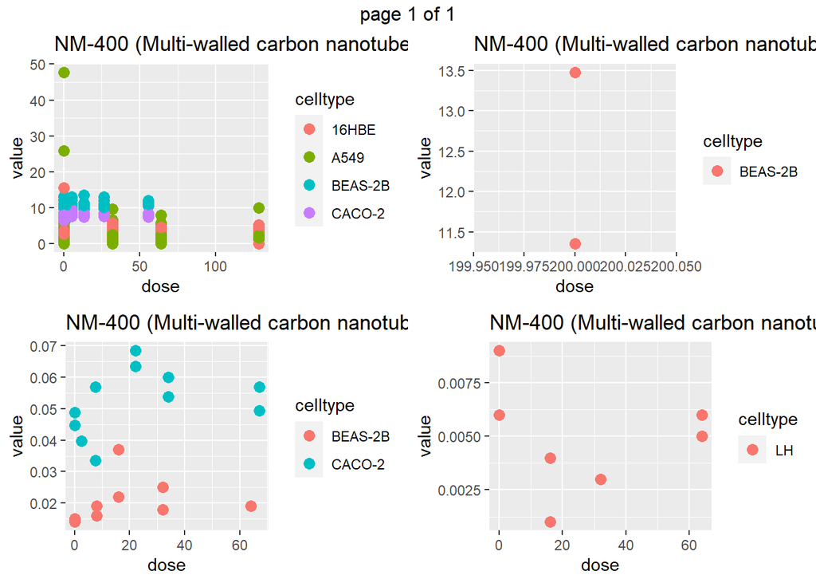

```
##
## $`NM-110 (Zinc Oxide, uncoated)`
```

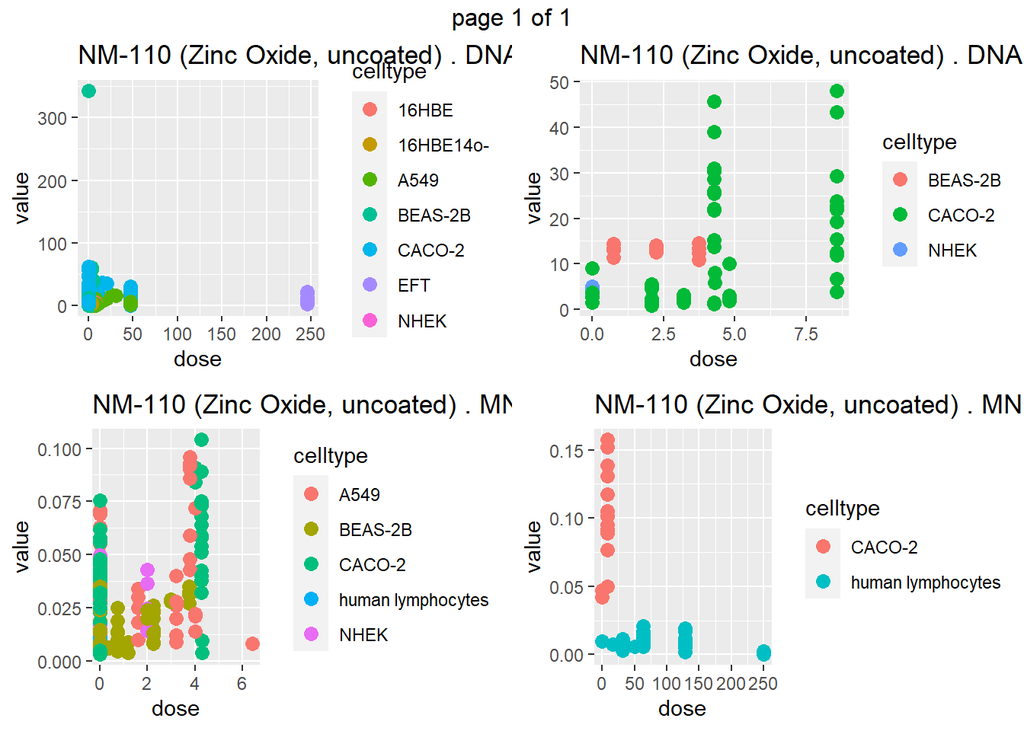

```r
nmplot.cat(data.nm=invitrodata, data.control=controldata, id="experimentID", nano="name", response="value", dose="concentration", type="dose", nrow=2, ncol=2, vars=c("endpoint","concentration_unit"), x.cat="celltype")
```

## 4.2 Testing monotonic trend in the dose-response relationship

### Isotonic means plot

Isotonic means can be plotted together with the data points as follows:

```
## $`NM-400 (Multi-walled carbon nanotubes)`
```

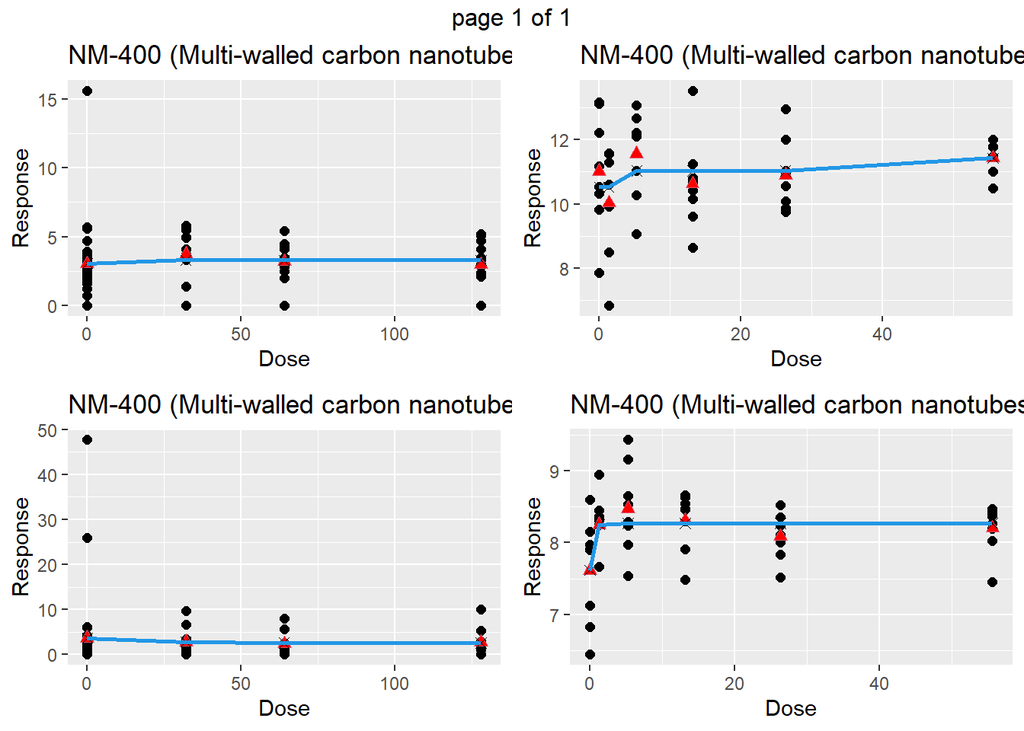

```
##
## $`NM-110 (Zinc Oxide, uncoated)`
```

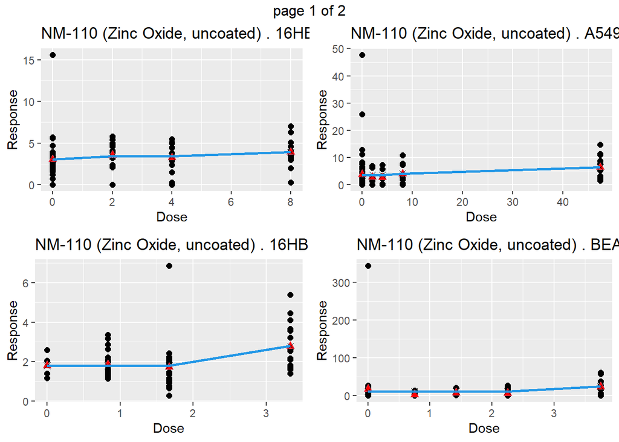

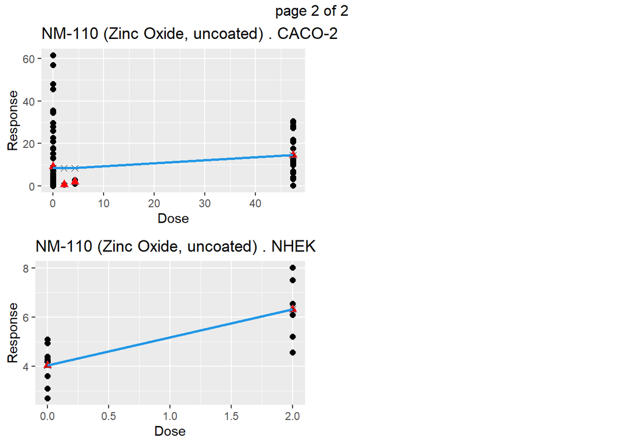

```r
Isoplot(data.nm=invitrodata, data.control=controldata, id="experimentID",
        nano="name", response="value", dose="concentration", end="endpoint",
        end.cat="DNA STRAND BREAKS", unit="concentration_unit", unit.cat="ug/cm2",
        dose.type="dose", control.opt="all", vars="celltype", nrow=2, ncol=2)
```

By adding “`celltype`” in argument “`vars`”, data of each nanomaterial is split according to different cell types.

### Testing the monotonic trend

Analysis of the monotonic trend in the dose-response relationship can be performed for each cell type in each nanomaterial. The data of each nanomaterial can be split according to the unique values of the cell type, and the data can be split automatically inside the function `Isotest`.